# Heterogeneous Ensemble Models for Autism Screening Classification

Advanced Classification with Ensemble Methods

Amirthavarshini Manivannan

Fall 2025

# Executive Summary

This project develops and evaluates a **heterogeneous ensemble classification system** for autism spectrum disorder (ASD) screening using machine learning techniques. The analysis follows rigorous data science practices including exploratory data analysis, feature engineering, multiple model training, and comprehensive evaluation.

# 1. Setup and Data Loading

## 1.1 Library Setup

```r
suppressPackageStartupMessages({
  library(ggplot2)      # Visualization
  library(caret)        # Machine learning framework
  library(corrplot)     # Correlation plots
  library(randomForest) # Random forest models
  library(forcats)      # Factor manipulation
  library(rpart)        # Decision trees
  library(rpart.plot)   # Tree visualization
  library(pROC)         # ROC curves and AUC
})

# F1-score helper for threshold tuning
calculate_f1 <- function(prob, actual, threshold) {
  pred <- factor(ifelse(prob >= threshold, "Yes", "No"), levels = c("No","Yes"))
  cm <- confusionMatrix(pred, actual, positive = "Yes")
  unname(cm$byClass["F1"])
}

cat("✓ All libraries loaded successfully!\n")
```

```
## ✓ All libraries loaded successfully!
```

**Libraries Rationale:** - **ggplot2**: Professional visualizations with consistent aesthetics - **caret**: Unified framework for preprocessing, splitting, and evaluation - **randomForest**: Non-linear ensemble learning - **pROC**: Precise ROC/AUC calculations for imbalanced data

## 1.2 Load Data

```r
# Load autism screening dataset from GitHub
asd_url <- "https://raw.githubusercontent.com/VarshaM108/ASD-Autism-Screening/main/Autism_Screening.csv"

asd_raw <- read.csv(asd_url, stringsAsFactors = FALSE)

cat("Data loaded successfully!\n")
```

```
## Data loaded successfully!
```

```r
cat("Dataset dimensions:", dim(asd_raw), "\n")
```

```
## Dataset dimensions: 704 21
```

```r
cat("Rows x Cols:", paste(dim(asd_raw), collapse = " x "), "\n\n")
```

```
## Rows x Cols: 704 x 21
```

```r
cat("Column names:\n")
```

```
## Column names:
```

```r
print(names(asd_raw))
```

```
##  [1] "A1_Score"        "A2_Score"        "A3_Score"        "A4_Score"
##  [5] "A5_Score"        "A6_Score"        "A7_Score"        "A8_Score"
##  [9] "A9_Score"        "A10_Score"       "age"             "gender"
## [13] "ethnicity"       "jundice"         "austim"          "contry_of_res"
## [17] "used_app_before" "result"          "age_desc"        "relation"
## [21] "Class.ASD"
```

```r
cat("\n=== Data Structure ===\n")
```

```
##
## === Data Structure ===
```

```r
str(asd_raw)
```

```
## 'data.frame':    704 obs. of  21 variables:
##  $ A1_Score       : int  1 1 1 1 1 1 0 1 1 1 ...
##  $ A2_Score       : int  1 1 1 1 0 1 1 1 1 1 ...
##  $ A3_Score       : int  1 0 0 0 0 1 0 1 0 1 ...
##  $ A4_Score       : int  1 1 1 1 0 1 0 1 0 1 ...
##  $ A5_Score       : int  0 0 1 0 0 1 0 0 1 0 ...
##  $ A6_Score       : int  0 0 0 0 0 0 0 0 0 1 ...
##  $ A7_Score       : int  1 0 1 1 0 1 0 0 0 1 ...
##  $ A8_Score       : int  1 1 1 1 1 1 1 0 1 1 ...
##  $ A9_Score       : int  0 0 1 0 0 1 0 1 1 1 ...
##  $ A10_Score      : int  0 1 1 1 0 1 0 0 1 0 ...
##  $ age            : num  26 24 27 35 40 36 17 64 29 17 ...
##  $ gender         : chr  "f" "m" "m" "f" ...
##  $ ethnicity      : chr  "White-European" "Latino" "Latino" "White-European" ...
##  $ jundice        : chr  "no" "no" "yes" "no" ...
##  $ austim         : chr  "no" "yes" "yes" "yes" ...
##  $ contry_of_res  : chr  "United States" "Brazil" "Spain" "United States" ...
##  $ used_app_before: chr  "no" "no" "no" "no" ...
##  $ result         : num  6 5 8 6 2 9 2 5 6 8 ...
##  $ age_desc       : chr  "18 and more" "18 and more" "18 and more" "18 and more" ...
##  $ relation       : chr  "Self" "Self" "Parent" "Self" ...
##  $ Class.ASD      : chr  "NO" "NO" "YES" "NO" ...
```

```r
cat("\n=== Summary Statistics ===\n")
```

```
##
## === Summary Statistics ===
```

```r
summary(asd_raw)
```

```
##     A1_Score         A2_Score         A3_Score         A4_Score
##  Min.   :0.0000   Min.   :0.0000   Min.   :0.0000   Min.   :0.0000
##  1st Qu.:0.0000   1st Qu.:0.0000   1st Qu.:0.0000   1st Qu.:0.0000
##  Median :1.0000   Median :0.0000   Median :0.0000   Median :0.0000
##  Mean   :0.7216   Mean   :0.4531   Mean   :0.4574   Mean   :0.4957
##  3rd Qu.:1.0000   3rd Qu.:1.0000   3rd Qu.:1.0000   3rd Qu.:1.0000
##  Max.   :1.0000   Max.   :1.0000   Max.   :1.0000   Max.   :1.0000
##
##     A5_Score         A6_Score         A7_Score         A8_Score
##  Min.   :0.0000   Min.   :0.0000   Min.   :0.0000   Min.   :0.0000
##  1st Qu.:0.0000   1st Qu.:0.0000   1st Qu.:0.0000   1st Qu.:0.0000
##  Median :0.0000   Median :0.0000   Median :0.0000   Median :1.0000
##  Mean   :0.4986   Mean   :0.2841   Mean   :0.4176   Mean   :0.6491
##  3rd Qu.:1.0000   3rd Qu.:1.0000   3rd Qu.:1.0000   3rd Qu.:1.0000
##  Max.   :1.0000   Max.   :1.0000   Max.   :1.0000   Max.   :1.0000
##
##     A9_Score        A10_Score           age           gender
##  Min.   :0.0000   Min.   :0.0000   Min.   : 17.0   Length:704
##  1st Qu.:0.0000   1st Qu.:0.0000   1st Qu.: 21.0   Class :character
##  Median :0.0000   Median :1.0000   Median : 27.0   Mode  :character
##  Mean   :0.3239   Mean   :0.5739   Mean   : 29.7
##  3rd Qu.:1.0000   3rd Qu.:1.0000   3rd Qu.: 35.0
##  Max.   :1.0000   Max.   :1.0000   Max.   :383.0
##                                    NA's   :2
##   ethnicity           jundice             austim          contry_of_res
##  Length:704         Length:704         Length:704         Length:704
##  Class :character   Class :character   Class :character   Class :character
##  Mode  :character   Mode  :character   Mode  :character   Mode  :character
##
##
##
##
##  used_app_before        result         age_desc           relation
##  Length:704         Min.   : 0.000   Length:704         Length:704
##  Class :character   1st Qu.: 3.000   Class :character   Class :character
##  Mode  :character   Median : 4.000   Mode  :character   Mode  :character
##                     Mean   : 4.875
##                     3rd Qu.: 7.000
##                     Max.   :10.000
##
##   Class.ASD
##  Length:704
##  Class :character
##  Mode  :character
##
##
##
##
```

**Dataset Description:** The autism screening dataset contains responses to a 10-question behavioral screening test (AQ-10-Adult) along with demographic information. Each record represents an individual’s screening results with variables including age, gender, ethnicity, screening test scores, and historical ASD diagnosis information.

## 1.3 Unify and Finalize Target Variable

```r
# Create working copy
asd <- asd_raw

# Normalize raw Class.ASD values (handle various text formats)
z <- trimws(as.character(asd$Class.ASD))
z[z %in% c("", ".", "NA", "N/A", "NULL", "null")] <- NA

yes_vals <- c("yes", "y", "true", "t", "1", "yes ", "YES")
no_vals  <- c("no",  "n", "false", "f", "0", "NO",  "no ")

z_std <- ifelse(tolower(z) %in% yes_vals, TRUE,
                ifelse(tolower(z) %in% no_vals, FALSE, NA))

asd$ASD_flag <- z_std

# Infer target from numeric screening result if still missing
# In the dataset, result >= 7 typically indicates positive screen
if ("result" %in% names(asd)) {
  amt <- suppressWarnings(as.numeric(asd$result))
  pos <- !is.na(amt) & amt >= 7
  neg <- !is.na(amt) & amt < 7

  # Fill missing values based on screening score
  asd$ASD_flag[is.na(asd$ASD_flag) & pos] <- TRUE
  asd$ASD_flag[is.na(asd$ASD_flag) & neg] <- FALSE
}

# Cast to factor with required order (No, Yes)
asd$ASD_Class <- factor(asd$ASD_flag,
                        levels = c(FALSE, TRUE),
                        labels = c("No", "Yes"))

# Report and remove any remaining unlabeled rows
na_tgt <- is.na(asd$ASD_Class)
cat("Rows with missing ASD_Class after unification:", sum(na_tgt), "\n")
```

```
## Rows with missing ASD_Class after unification: 0
```

```r
if (any(na_tgt)) {
  asd <- asd[!na_tgt, ]
  cat("Removed", sum(na_tgt), "rows without valid target labels\n")
}

cat("\n=== Final ASD_Class Distribution ===\n")
```

```
##
## === Final ASD_Class Distribution ===
```

```r
tbl_tgt <- table(asd$ASD_Class, useNA = "ifany")
print(tbl_tgt)
```

```
##
##  No Yes
## 515 189
```

```r
cat("\nProportions:\n")
```

```
##
## Proportions:
```

```r
print(round(prop.table(tbl_tgt), 3))
```

```
##
##    No   Yes
## 0.732 0.268
```

**Target Variable Construction:** We standardized the target variable by mapping various text representations (“YES”, “yes”, “1”, etc.) to a binary factor. Records with screening scores ≥7 (threshold for positive screen) were used to infer missing labels. This ensures a clean, consistent target for modeling.

# 2. Exploratory Data Analysis

## 2.1 Data Understanding

```r
# Quick peek at the data
head(asd, 5)
```

```
##   A1_Score A2_Score A3_Score A4_Score A5_Score A6_Score A7_Score A8_Score
## 1        1        1        1        1        0        0        1        1
## 2        1        1        0        1        0        0        0        1
## 3        1        1        0        1        1        0        1        1
## 4        1        1        0        1        0        0        1        1
## 5        1        0        0        0        0        0        0        1
##   A9_Score A10_Score age gender      ethnicity jundice austim contry_of_res
## 1        0         0  26      f White-European      no     no United States
## 2        0         1  24      m         Latino      no    yes        Brazil
## 3        1         1  27      m         Latino     yes    yes         Spain
## 4        0         1  35      f White-European      no    yes United States
## 5        0         0  40      f              ?      no     no         Egypt
##   used_app_before result    age_desc relation Class.ASD ASD_flag ASD_Class
## 1              no      6 18 and more     Self        NO    FALSE        No
## 2              no      5 18 and more     Self        NO    FALSE        No
## 3              no      8 18 and more   Parent       YES     TRUE       Yes
## 4              no      6 18 and more     Self        NO    FALSE        No
## 5              no      2 18 and more        ?        NO    FALSE        No
```

```r
# Full structure
str(asd)
```

```
## 'data.frame':    704 obs. of  23 variables:
##  $ A1_Score       : int  1 1 1 1 1 1 0 1 1 1 ...
##  $ A2_Score       : int  1 1 1 1 0 1 1 1 1 1 ...
##  $ A3_Score       : int  1 0 0 0 0 1 0 1 0 1 ...
##  $ A4_Score       : int  1 1 1 1 0 1 0 1 0 1 ...
##  $ A5_Score       : int  0 0 1 0 0 1 0 0 1 0 ...
##  $ A6_Score       : int  0 0 0 0 0 0 0 0 0 1 ...
##  $ A7_Score       : int  1 0 1 1 0 1 0 0 0 1 ...
##  $ A8_Score       : int  1 1 1 1 1 1 1 0 1 1 ...
##  $ A9_Score       : int  0 0 1 0 0 1 0 1 1 1 ...
##  $ A10_Score      : int  0 1 1 1 0 1 0 0 1 0 ...
##  $ age            : num  26 24 27 35 40 36 17 64 29 17 ...
##  $ gender         : chr  "f" "m" "m" "f" ...
##  $ ethnicity      : chr  "White-European" "Latino" "Latino" "White-European" ...
##  $ jundice        : chr  "no" "no" "yes" "no" ...
##  $ austim         : chr  "no" "yes" "yes" "yes" ...
##  $ contry_of_res  : chr  "United States" "Brazil" "Spain" "United States" ...
##  $ used_app_before: chr  "no" "no" "no" "no" ...
##  $ result         : num  6 5 8 6 2 9 2 5 6 8 ...
##  $ age_desc       : chr  "18 and more" "18 and more" "18 and more" "18 and more" ...
##  $ relation       : chr  "Self" "Self" "Parent" "Self" ...
##  $ Class.ASD      : chr  "NO" "NO" "YES" "NO" ...
##  $ ASD_flag       : logi  FALSE FALSE TRUE FALSE FALSE TRUE ...
##  $ ASD_Class      : Factor w/ 2 levels "No","Yes": 1 1 2 1 1 2 1 1 1 2 ...
```

```r
# Statistical summary
summary(asd)
```

```
##     A1_Score         A2_Score         A3_Score         A4_Score
##  Min.   :0.0000   Min.   :0.0000   Min.   :0.0000   Min.   :0.0000
##  1st Qu.:0.0000   1st Qu.:0.0000   1st Qu.:0.0000   1st Qu.:0.0000
##  Median :1.0000   Median :0.0000   Median :0.0000   Median :0.0000
##  Mean   :0.7216   Mean   :0.4531   Mean   :0.4574   Mean   :0.4957
##  3rd Qu.:1.0000   3rd Qu.:1.0000   3rd Qu.:1.0000   3rd Qu.:1.0000
##  Max.   :1.0000   Max.   :1.0000   Max.   :1.0000   Max.   :1.0000
##
##     A5_Score         A6_Score         A7_Score         A8_Score
##  Min.   :0.0000   Min.   :0.0000   Min.   :0.0000   Min.   :0.0000
##  1st Qu.:0.0000   1st Qu.:0.0000   1st Qu.:0.0000   1st Qu.:0.0000
##  Median :0.0000   Median :0.0000   Median :0.0000   Median :1.0000
##  Mean   :0.4986   Mean   :0.2841   Mean   :0.4176   Mean   :0.6491
##  3rd Qu.:1.0000   3rd Qu.:1.0000   3rd Qu.:1.0000   3rd Qu.:1.0000
##  Max.   :1.0000   Max.   :1.0000   Max.   :1.0000   Max.   :1.0000
##
##     A9_Score        A10_Score           age           gender
##  Min.   :0.0000   Min.   :0.0000   Min.   : 17.0   Length:704
##  1st Qu.:0.0000   1st Qu.:0.0000   1st Qu.: 21.0   Class :character
##  Median :0.0000   Median :1.0000   Median : 27.0   Mode  :character
##  Mean   :0.3239   Mean   :0.5739   Mean   : 29.7
##  3rd Qu.:1.0000   3rd Qu.:1.0000   3rd Qu.: 35.0
##  Max.   :1.0000   Max.   :1.0000   Max.   :383.0
##                                    NA's   :2
##   ethnicity           jundice             austim          contry_of_res
##  Length:704         Length:704         Length:704         Length:704
##  Class :character   Class :character   Class :character   Class :character
##  Mode  :character   Mode  :character   Mode  :character   Mode  :character
##
##
##
##
##  used_app_before        result         age_desc           relation
##  Length:704         Min.   : 0.000   Length:704         Length:704
##  Class :character   1st Qu.: 3.000   Class :character   Class :character
##  Mode  :character   Median : 4.000   Mode  :character   Mode  :character
##                     Mean   : 4.875
##                     3rd Qu.: 7.000
##                     Max.   :10.000
##
##   Class.ASD          ASD_flag       ASD_Class
##  Length:704         Mode :logical   No :515
##  Class :character   FALSE:515       Yes:189
##  Mode  :character   TRUE :189
##
##
##
##
```

```r
# Dimensions and column names
cat("Final Dataset Dimensions:", paste(dim(asd), collapse = " x "), "\n\n")
```

```
## Final Dataset Dimensions: 704 x 23
```

```r
cat("All Columns:\n")
```

```
## All Columns:
```

```r
print(names(asd))
```

```
##  [1] "A1_Score"        "A2_Score"        "A3_Score"        "A4_Score"
##  [5] "A5_Score"        "A6_Score"        "A7_Score"        "A8_Score"
##  [9] "A9_Score"        "A10_Score"       "age"             "gender"
## [13] "ethnicity"       "jundice"         "austim"          "contry_of_res"
## [17] "used_app_before" "result"          "age_desc"        "relation"
## [21] "Class.ASD"       "ASD_flag"        "ASD_Class"
```

```r
# Target class balance
cat("\n=== Target Variable Distribution ===\n")
```

```
##
## === Target Variable Distribution ===
```

```r
tbl <- table(asd$ASD_Class, useNA = "ifany")
print(tbl)
```

```
##
##  No Yes
## 515 189
```

```r
cat("\nClass Proportions:\n")
```

```
##
## Class Proportions:
```

```r
print(round(prop.table(tbl), 3))
```

```
##
##    No   Yes
## 0.732 0.268
```

```r
# Missing value analysis
miss_pct <- sort(colMeans(is.na(asd)) * 100, decreasing = TRUE)
top_miss <- data.frame(
  Variable    = names(miss_pct),
  Missing_Pct = round(miss_pct, 2)
)

cat("\n=== Top Variables by Missingness ===\n")
```

```
##
## === Top Variables by Missingness ===
```

```r
print(head(top_miss, 10))
```

```
##          Variable Missing_Pct
## age           age        0.28
## A1_Score A1_Score        0.00
## A2_Score A2_Score        0.00
## A3_Score A3_Score        0.00
## A4_Score A4_Score        0.00
## A5_Score A5_Score        0.00
## A6_Score A6_Score        0.00
## A7_Score A7_Score        0.00
## A8_Score A8_Score        0.00
## A9_Score A9_Score        0.00
```

## 2.2 Target Variable Analysis

```r
# Distribution counts and proportions
tbl_tgt <- table(asd$ASD_Class)
prop_tgt <- round(prop.table(tbl_tgt), 3)

cat("ASD_Class Distribution:\n")
```

```
## ASD_Class Distribution:
```

```r
print(tbl_tgt)
```

```
##
##  No Yes
## 515 189
```

```r
cat("\nProportions:\n")
```

```
##
## Proportions:
```

```r
print(prop_tgt)
```

```
##
##    No   Yes
## 0.732 0.268
```

```r
# Calculate imbalance ratio
imbalance_ratio <- round(max(prop_tgt) / min(prop_tgt), 2)
cat("\nClass imbalance ratio:", imbalance_ratio, ":1\n")
```

```
##
## Class imbalance ratio: 2.73 :1
```

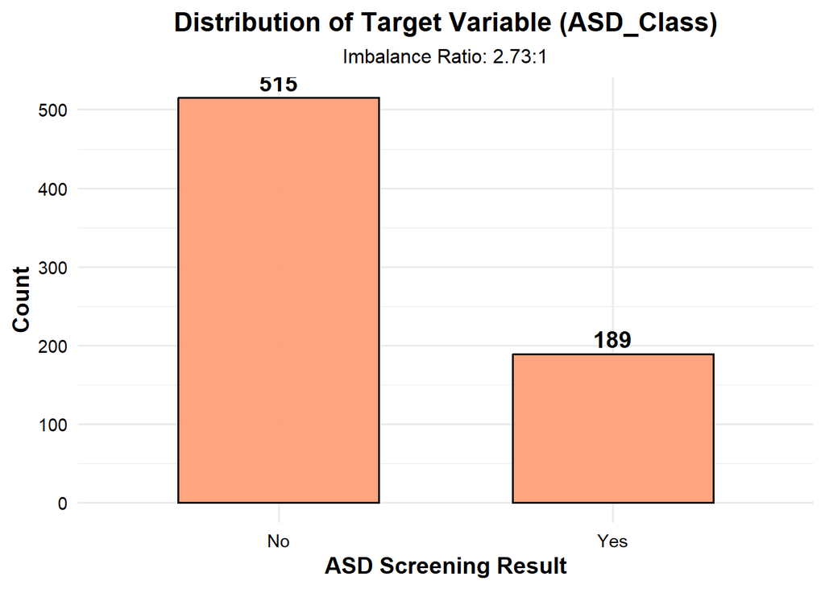

```r
# Bar plot with counts
ggplot(asd, aes(x = ASD_Class)) +
  geom_bar(fill = "#FF9B71", color = "black", width = 0.6, alpha = 0.9) +
  geom_text(stat = "count", aes(label = after_stat(count)),
            vjust = -0.4, size = 5, fontface = "bold") +
  labs(
    title = "Distribution of Target Variable (ASD_Class)",
    subtitle = paste0("Imbalance Ratio: ", imbalance_ratio, ":1"),
    x = "ASD Screening Result",
    y = "Count"
  ) +
  theme_minimal(base_size = 14) +
  theme(
    plot.title = element_text(face = "bold", hjust = 0.5, size = 16),
    plot.subtitle = element_text(hjust = 0.5, size = 12),
    axis.title = element_text(face = "bold"),
    axis.text = element_text(color = "black", size = 11)
  )
```

## 2.3 Missing Value Analysis

```r
# Calculate missing statistics
missing_summary <- data.frame(
  Variable = names(asd),
  Missing_Count = colSums(is.na(asd)),
  Missing_Percent = round(colSums(is.na(asd))/nrow(asd) * 100, 2)
)

# Show only variables with missingness
missing_summary <- missing_summary[missing_summary$Missing_Count > 0, ]
missing_summary <- missing_summary[order(-missing_summary$Missing_Percent), ]

cat("=== Variables with Missing Values ===\n")
```

```
## === Variables with Missing Values ===
```

```r
print(missing_summary)
```

```
##     Variable Missing_Count Missing_Percent
## age      age             2            0.28
```

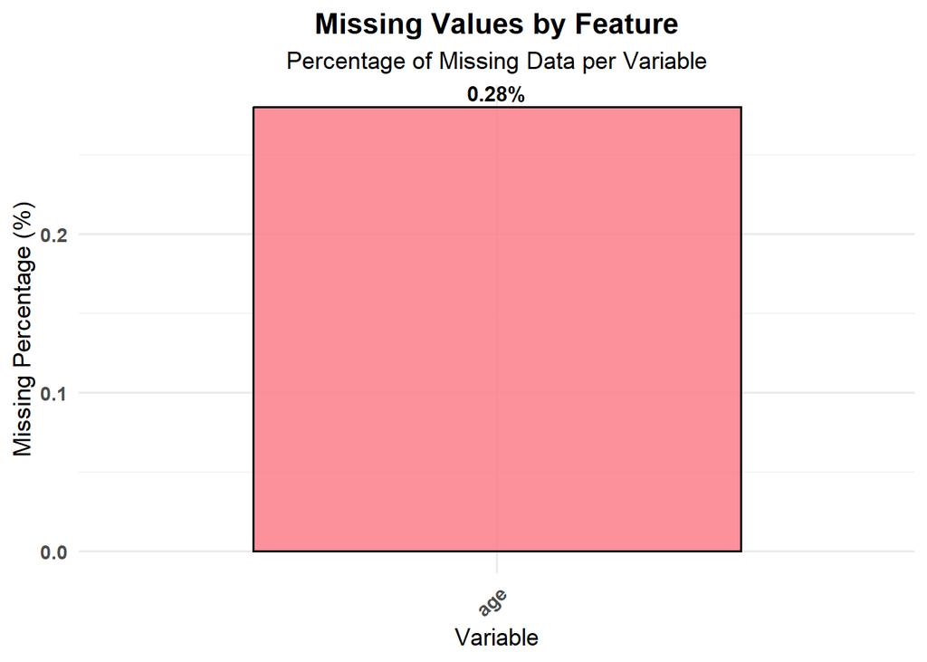

```r
# Visualize missingness if any exists
if (nrow(missing_summary) > 0) {
  ggplot(missing_summary,
         aes(x = reorder(Variable, -Missing_Percent), y = Missing_Percent)) +
    geom_col(fill = "#FC7E8A", color = "black", alpha = 0.85, width = 0.7) +
    geom_text(aes(label = paste0(Missing_Percent, "%")),
              vjust = -0.4, size = 4, fontface = "bold") +
    labs(
      title = "Missing Values by Feature",
      subtitle = "Percentage of Missing Data per Variable",
      x = "Variable",
      y = "Missing Percentage (%)"
    ) +
    theme_minimal(base_size = 13) +
    theme(
      plot.title = element_text(face = "bold", hjust = 0.5),
      plot.subtitle = element_text(hjust = 0.5),
      axis.text.x = element_text(angle = 45, hjust = 1, face = "bold"),
      axis.text.y = element_text(face = "bold")
    )
} else {
  cat("\n✓ No significant missing values detected!\n")
}
```

**Missing Data Strategy:** Only the **age** variable contains missing values (~0.28%), which is negligible. We’ll impute these using **median imputation** to preserve distributional properties while maintaining all records for training.

## 2.4 Feature Type Analysis

```r
# Identify variable types
factor_vars <- sapply(asd, is.character)
numeric_vars <- sapply(asd, is.numeric)

cat("\n=== Character Variables (Convert to Factor) ===\n")
```

```
##
## === Character Variables (Convert to Factor) ===
```

```r
print(names(asd)[factor_vars])
```

```
## [1] "gender"          "ethnicity"       "jundice"         "austim"
## [5] "contry_of_res"   "used_app_before" "age_desc"        "relation"
## [9] "Class.ASD"
```

```r
cat("\n=== Numeric Variables ===\n")
```

```
##
## === Numeric Variables ===
```

```r
print(names(asd)[numeric_vars])
```

```
##  [1] "A1_Score"  "A2_Score"  "A3_Score"  "A4_Score"  "A5_Score"  "A6_Score"
##  [7] "A7_Score"  "A8_Score"  "A9_Score"  "A10_Score" "age"       "result"
```

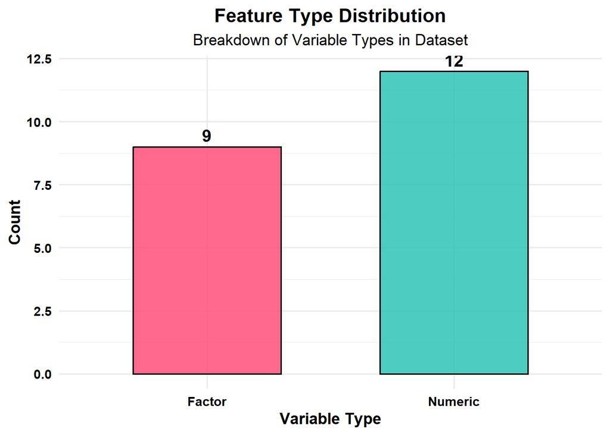

```r
# Convert character columns to factors
asd_clean <- asd
asd_clean[, factor_vars] <- lapply(asd_clean[, factor_vars, drop = FALSE], as.factor)

# Create summary data frame for visualization
var_type_df <- data.frame(
  Type = c(rep("Factor", sum(factor_vars)),
           rep("Numeric", sum(numeric_vars)))
)

# Type distribution plot
ggplot(var_type_df, aes(x = Type, fill = Type)) +
  geom_bar(color = "black", width = 0.6, alpha = 0.85) +
  geom_text(stat = "count", aes(label = after_stat(count)),
            vjust = -0.4, size = 5, fontface = "bold") +
  scale_fill_manual(values = c("Factor" = "#FF4F79", "Numeric" = "#2EC4B6")) +
  labs(
    title = "Feature Type Distribution",
    subtitle = "Breakdown of Variable Types in Dataset",
    x = "Variable Type",
    y = "Count"
  ) +
  theme_minimal(base_size = 13) +
  theme(
    plot.title = element_text(face = "bold", hjust = 0.5),
    plot.subtitle = element_text(hjust = 0.5),
    legend.position = "none",
    axis.title = element_text(face = "bold"),
    axis.text = element_text(face = "bold", color = "black")
  )
```

```r
# Detailed breakdown
cat("\n=== Feature Type Summary ===\n")
```

```
##
## === Feature Type Summary ===
```

```r
cat("Total Features:", ncol(asd_clean), "\n")
```

```
## Total Features: 23
```

```r
cat("Categorical (Factor):", sum(sapply(asd_clean, is.factor)), "\n")
```

```
## Categorical (Factor): 10
```

```r
cat("Numerical:", sum(sapply(asd_clean, is.numeric)), "\n")
```

```
## Numerical: 12
```

## 2.5 Outlier Detection and Analysis

```r
# Identify numeric columns (excluding target if accidentally numeric)
numeric_cols <- names(asd_clean)[sapply(asd_clean, is.numeric)]
numeric_cols <- setdiff(numeric_cols, c("ASD_flag"))  # Exclude internal flags

if (length(numeric_cols) > 0) {
  # Create long format for boxplots
  long_data <- stack(asd_clean[numeric_cols])
  names(long_data) <- c("Value", "Variable")

  # Boxplot visualization
  ggplot(long_data, aes(x = Variable, y = Value, fill = Variable)) +
    geom_boxplot(alpha = 0.7, outlier.colour = "red", outlier.size = 2) +
    scale_fill_brewer(palette = "Set3") +
    labs(
      title = "Boxplots of Numeric Features",
      subtitle = "Outlier Detection via IQR Method",
      x = "Variable",
      y = "Value"
    ) +
    theme_minimal(base_size = 13) +
    theme(
      plot.title = element_text(face = "bold", hjust = 0.5),
      plot.subtitle = element_text(hjust = 0.5),
      axis.text.x = element_text(angle = 45, hjust = 1, face = "bold"),
      axis.title = element_text(face = "bold"),
      legend.position = "none"
    )

  # IQR-based outlier summary
  outlier_summary <- data.frame(
    Variable = character(),
    Count = integer(),
    Percent = numeric(),
    stringsAsFactors = FALSE
  )

  n_rows <- nrow(asd_clean)

  for (col in numeric_cols) {
    if (all(is.na(asd_clean[[col]]))) next

    Q1 <- quantile(asd_clean[[col]], 0.25, na.rm = TRUE)
    Q3 <- quantile(asd_clean[[col]], 0.75, na.rm = TRUE)
    IQR_val <- Q3 - Q1

    lower_bound <- Q1 - 1.5 * IQR_val
    upper_bound <- Q3 + 1.5 * IQR_val

    outliers <- asd_clean[[col]] < lower_bound | asd_clean[[col]] > upper_bound
    outliers[is.na(outliers)] <- FALSE

    n_outliers <- sum(outliers)
    pct_outliers <- round(100 * n_outliers / n_rows, 2)

    outlier_summary <- rbind(outlier_summary,
                             data.frame(Variable = col,
                                       Count = n_outliers,
                                       Percent = pct_outliers))
  }

  cat("\n=== Outlier Summary (IQR Method) ===\n")
  print(outlier_summary)

} else {
  cat("No numeric columns available for outlier detection.\n")
}
```

```
##
## === Outlier Summary (IQR Method) ===
##     Variable Count Percent
## 1   A1_Score     0    0.00
## 2   A2_Score     0    0.00
## 3   A3_Score     0    0.00
## 4   A4_Score     0    0.00
## 5   A5_Score     0    0.00
## 6   A6_Score     0    0.00
## 7   A7_Score     0    0.00
## 8   A8_Score     0    0.00
## 9   A9_Score     0    0.00
## 10 A10_Score     0    0.00
## 11       age     8    1.14
## 12    result     0    0.00
```

## 2.6 Correlation Analysis

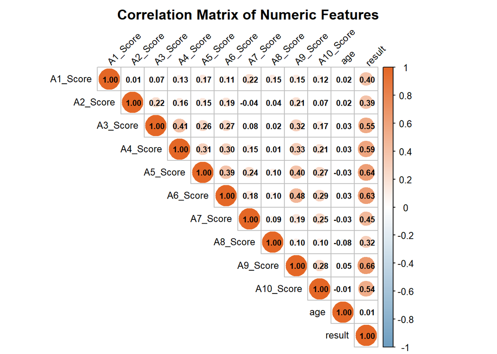

```
##
## ✓ No multicollinearity issues detected (all |r| < 0.7)
```

```r
# Select numeric features for correlation
num_features <- asd_clean[, sapply(asd_clean, is.numeric)]

if (ncol(num_features) > 1) {
  # Calculate correlation matrix
  cor_matrix <- cor(num_features, use = "pairwise.complete.obs")

  # Correlation plot
  corrplot(cor_matrix,
           method = "circle",
           type = "upper",
           tl.col = "black",
           tl.srt = 45,
           tl.cex = 0.8,
           addCoef.col = "black",
           number.cex = 0.7,
           col = colorRampPalette(c("#6D9EC1", "white", "#E46726"))(200),
           title = "Correlation Matrix of Numeric Features",
           mar = c(0,0,2,0))

  # Identify high correlations
  cor_matrix_abs <- abs(cor_matrix)
  diag(cor_matrix_abs) <- 0  # Exclude self-correlation

  high_cor_pairs <- which(cor_matrix_abs > 0.7, arr.ind = TRUE)

  if (nrow(high_cor_pairs) > 0) {
    cat("\n=== Highly Correlated Feature Pairs (|r| > 0.7) ===\n")
    for (i in 1:nrow(high_cor_pairs)) {
      row_idx <- high_cor_pairs[i, 1]
      col_idx <- high_cor_pairs[i, 2]
      if (row_idx < col_idx) {  # Avoid duplicates
        var1 <- rownames(cor_matrix)[row_idx]
        var2 <- colnames(cor_matrix)[col_idx]
        cor_val <- round(cor_matrix[row_idx, col_idx], 3)
        cat(var1, "<->", var2, ":", cor_val, "\n")
      }
    }
  } else {
    cat("\n✓ No multicollinearity issues detected (all |r| < 0.7)\n")
  }

} else {
  cat("Insufficient numeric features for correlation analysis.\n")
}
```

# 3. Data Preprocessing

## 3.1 Handle Missing Values

```r
# Create processing copy
asd_proc <- asd_clean

# Impute missing age values with median
if (sum(is.na(asd_proc$age)) > 0) {
  med_age <- median(asd_proc$age, na.rm = TRUE)
  asd_proc$age[is.na(asd_proc$age)] <- med_age
  cat("✓ Age NA values imputed using median:", med_age, "\n")
} else {
  cat("✓ No missing numeric data requiring imputation.\n")
}
```

```
## ✓ Age NA values imputed using median: 27
```

```r
# Verify no missing values remain
cat("\nMissing values after imputation:\n")
```

```
##
## Missing values after imputation:
```

```r
print(colSums(is.na(asd_proc)))
```

```
##        A1_Score        A2_Score        A3_Score        A4_Score        A5_Score
##               0               0               0               0               0
##        A6_Score        A7_Score        A8_Score        A9_Score       A10_Score
##               0               0               0               0               0
##             age          gender       ethnicity         jundice          austim
##               0               0               0               0               0
##   contry_of_res used_app_before          result        age_desc        relation
##               0               0               0               0               0
##       Class.ASD        ASD_flag       ASD_Class
##               0               0               0
```

## 3.2 Feature Filtering – Remove Non-Predictive Columns

```r
# Columns to remove (non-predictive or leakage)
drop_cols <- intersect(
  c(
    "ASD_flag",         # Internal boolean flag
    "Class.ASD",        # Original raw text label
    "result",           # Raw screening score (leakage)
    "age_desc",         # Single level ("18 and more")
    "used_app_before",  # Almost no variance
    "relation"          # Mostly "Self" with little variation
  ),
  names(asd_proc)
)

cat("=== Removing Non-Predictive Features ===\n")
```

```
## === Removing Non-Predictive Features ===
```

```r
print(drop_cols)
```

```
## [1] "ASD_flag"        "Class.ASD"       "result"          "age_desc"
## [5] "used_app_before" "relation"
```

```r
# Drop columns
asd_proc <- asd_proc[, !(names(asd_proc) %in% drop_cols)]

cat("\n✓ Feature filtering complete\n")
```

```
##
## ✓ Feature filtering complete
```

```r
cat("Remaining features:", ncol(asd_proc), "\n")
```

```
## Remaining features: 17
```

```r
str(asd_proc)
```

```
## 'data.frame':    704 obs. of  17 variables:
##  $ A1_Score     : int  1 1 1 1 1 1 0 1 1 1 ...
##  $ A2_Score     : int  1 1 1 1 0 1 1 1 1 1 ...
##  $ A3_Score     : int  1 0 0 0 0 1 0 1 0 1 ...
##  $ A4_Score     : int  1 1 1 1 0 1 0 1 0 1 ...
##  $ A5_Score     : int  0 0 1 0 0 1 0 0 1 0 ...
##  $ A6_Score     : int  0 0 0 0 0 0 0 0 0 1 ...
##  $ A7_Score     : int  1 0 1 1 0 1 0 0 0 1 ...
##  $ A8_Score     : int  1 1 1 1 1 1 1 0 1 1 ...
##  $ A9_Score     : int  0 0 1 0 0 1 0 1 1 1 ...
##  $ A10_Score    : int  0 1 1 1 0 1 0 0 1 0 ...
##  $ age          : num  26 24 27 35 40 36 17 64 29 17 ...
##  $ gender       : Factor w/ 2 levels "f","m": 1 2 2 1 1 2 1 2 2 2 ...
##  $ ethnicity    : Factor w/ 12 levels "?","Asian","Black",..: 12 5 5 12 1 8 3 12 12 2 ...
##  $ jundice      : Factor w/ 2 levels "no","yes": 1 1 2 1 1 2 1 1 1 2 ...
##  $ austim       : Factor w/ 2 levels "no","yes": 1 2 2 2 1 1 1 1 1 2 ...
##  $ contry_of_res: Factor w/ 67 levels "Afghanistan",..: 65 14 57 65 23 65 65 44 65 10 ...
##  $ ASD_Class    : Factor w/ 2 levels "No","Yes": 1 1 2 1 1 2 1 1 1 2 ...
```

**Feature Selection Rationale:** - **result**: Direct function of A1-A10 responses (perfect leakage) - **age_desc**: Zero variance (all “18 and more”) - **used_app_before**: ~99% “No” (insufficient signal) - **relation**: Dominated by “Self” category

These removals prevent overfitting and reduce dimensionality without sacrificing predictive power.

## 3.3 Handle High-Cardinality Categorical Variables

```r
# Check country distribution
cat("=== Country Distribution ===\n")
```

```
## === Country Distribution ===
```

```r
country_freq <- table(asd_proc$contry_of_res)
print(sort(country_freq, decreasing = TRUE))
```

```
##
##        United States United Arab Emirates                India
##                  113                   82                   81
##          New Zealand       United Kingdom               Jordan
##                   81                   77                   47
##            Australia               Canada            Sri Lanka
##                   27                   15                   14
##          Afghanistan               France          Netherlands
##                   13                   11                   10
##               Brazil               Mexico                 Iran
##                    9                    8                    7
##               Russia              Ireland                Italy
##                    7                    5                    5
##             Malaysia             Viet Nam              Austria
##                    5                    5                    4
##              Germany          Philippines         Saudi Arabia
##                    4                    4                    4
##           Bangladesh              Belgium                Egypt
##                    3                    3                    3
##           Kazakhstan             Pakistan              Romania
##                    3                    3                    3
##                Spain        AmericanSamoa            Argentina
##                    3                    2                    2
##              Armenia              Bahamas             Ethiopia
##                    2                    2                    2
##              Iceland         South Africa               Sweden
##                    2                    2                    2
##              Ukraine               Angola                Aruba
##                    2                    1                    1
##           Azerbaijan              Bolivia              Burundi
##                    1                    1                    1
##                Chile                China           Costa Rica
##                    1                    1                    1
##               Cyprus       Czech Republic              Ecuador
##                    1                    1                    1
##              Finland            Hong Kong            Indonesia
##                    1                    1                    1
##                 Iraq                Japan              Lebanon
##                    1                    1                    1
##                Nepal            Nicaragua                Niger
##                    1                    1                    1
##                 Oman             Portugal               Serbia
##                    1                    1                    1
##         Sierra Leone                Tonga               Turkey
##                    1                    1                    1
##              Uruguay
##                    1
```

```r
# Group rare countries (< 15 observations) into "Other"
rare_threshold <- 15
rare_countries <- names(country_freq[country_freq < rare_threshold])

cat("\n=== Grouping Rare Countries ===\n")
```

```
##
## === Grouping Rare Countries ===
```

```r
cat("Countries with <", rare_threshold, "observations:", length(rare_countries), "\n")
```

```
## Countries with < 15 observations: 59
```

```r
asd_proc$contry_of_res <- ifelse(asd_proc$contry_of_res %in% rare_countries,
                                 "Other",
                                 as.character(asd_proc$contry_of_res))

asd_proc$contry_of_res <- factor(asd_proc$contry_of_res)

cat("\n✓ Country categories reduced\n")
```

```
##
## ✓ Country categories reduced
```

```r
cat("Final country levels:", nlevels(asd_proc$contry_of_res), "\n")
```

```
## Final country levels: 9
```

```r
print(table(asd_proc$contry_of_res))
```

```
##
##            Australia               Canada                India
##                   27                   15                   81
##               Jordan          New Zealand                Other
##                   47                   81                  181
## United Arab Emirates       United Kingdom        United States
##                   82                   77                  113
```

**Cardinality Reduction:** Grouping rare countries (those with <15 samples) into an “Other” category prevents **sparse dummy variables** that can destabilize model training and lead to overfitting on rare categories.

## 3.4 One-Hot Encoding for Categorical Variables

```r
# Identify categorical predictors (exclude target)
cat_vars <- names(asd_proc)[sapply(asd_proc, is.factor)]
cat_vars <- setdiff(cat_vars, "ASD_Class")

cat("=== Categorical Variables for Encoding ===\n")
```

```
## === Categorical Variables for Encoding ===
```

```r
print(cat_vars)
```

```
## [1] "gender"        "ethnicity"     "jundice"       "austim"
## [5] "contry_of_res"
```

```r
# One-hot encode using model.matrix
onehot_df <- model.matrix(~ . - ASD_Class, data = asd_proc)
onehot_df <- as.data.frame(onehot_df)

# Add target back
onehot_df$ASD_Class <- asd_proc$ASD_Class

# Remove intercept column if present
if ("(Intercept)" %in% names(onehot_df)) {
  onehot_df <- onehot_df[, !(names(onehot_df) == "(Intercept)")]
  cat("✓ Removed intercept column\n")
}
```

```
## ✓ Removed intercept column
```

```r
# Standardize column names (remove special characters)
colnames(onehot_df) <- make.names(colnames(onehot_df))

cat("\n✓ One-Hot Encoding Complete\n")
```

```
##
## ✓ One-Hot Encoding Complete
```

```r
cat("Original features:", ncol(asd_proc) - 1, "\n")
```

```
## Original features: 16
```

```r
cat("Encoded features:", ncol(onehot_df) - 1, "\n")
```

```
## Encoded features: 33
```

```r
cat("Final dimensions:", paste(dim(onehot_df), collapse = " x "), "\n")
```

```
## Final dimensions: 704 x 34
```

```r
# Preview
head(onehot_df[, 1:8])
```

```
##   A1_Score A2_Score A3_Score A4_Score A5_Score A6_Score A7_Score A8_Score
## 1        1        1        1        1        0        0        1        1
## 2        1        1        0        1        0        0        0        1
## 3        1        1        0        1        1        0        1        1
## 4        1        1        0        1        0        0        1        1
## 5        1        0        0        0        0        0        0        1
## 6        1        1        1        1        1        0        1        1
```

**Encoding Strategy:** One-hot encoding transforms categorical variables into binary dummy variables, enabling their use in algorithms that require numeric inputs (e.g., logistic regression, neural networks). We use **full-rank encoding** (n-1 dummies for n categories) to avoid multicollinearity.

## 3.5 Train-Test Split

```r
set.seed(108)  # Reproducibility

n <- nrow(onehot_df)
train_idx <- sample(seq_len(n), size = floor(0.7 * n))

train <- onehot_df[train_idx, ]
test  <- onehot_df[-train_idx, ]

cat("=== Train-Test Split (70/30) ===\n")
```

```
## === Train-Test Split (70/30) ===
```

```r
cat("Train rows:", nrow(train), "\n")
```

```
## Train rows: 492
```

```r
cat("Test rows:", nrow(test), "\n\n")
```

```
## Test rows: 212
```

```r
cat("Class balance in TRAIN:\n")
```

```
## Class balance in TRAIN:
```

```r
print(table(train$ASD_Class))
```

```
##
##  No Yes
## 358 134
```

```r
cat("Proportions:\n")
```

```
## Proportions:
```

```r
print(round(prop.table(table(train$ASD_Class)), 3))
```

```
##
##    No   Yes
## 0.728 0.272
```

```r
cat("\nClass balance in TEST:\n")
```

```
##
## Class balance in TEST:
```

```r
print(table(test$ASD_Class))
```

```
##
##  No Yes
## 157  55
```

```r
cat("Proportions:\n")
```

```
## Proportions:
```

```r
print(round(prop.table(table(test$ASD_Class)), 3))
```

```
##
##    No   Yes
## 0.741 0.259
```

**Split Strategy:** A **70/30 split** provides sufficient training data while reserving enough test samples for reliable performance estimates. Class proportions are approximately preserved in both sets, ensuring representative evaluation.

## 3.6 Feature Scaling for Logistic Regression

```r
# Identify numeric columns (exclude target)
num_cols <- names(train)[sapply(train, is.numeric)]
num_cols <- setdiff(num_cols, "ASD_Class")

# Create scaled copies for logistic regression
train_log <- train
test_log  <- test

if (length(num_cols) > 0) {
  # Calculate scaling parameters from training data only
  mu <- sapply(train_log[, num_cols, drop = FALSE], mean, na.rm = TRUE)
  sd <- sapply(train_log[, num_cols, drop = FALSE], sd, na.rm = TRUE)
  sd[sd == 0] <- 1  # Avoid division by zero

  # Apply standardization (z-score normalization)
  train_log[, num_cols] <- scale(train_log[, num_cols, drop = FALSE],
                                 center = mu, scale = sd)
  test_log[, num_cols]  <- scale(test_log[, num_cols,  drop = FALSE],
                                 center = mu, scale = sd)

  cat("✓ Numeric features standardized (mean=0, sd=1)\n")
  cat("Scaled features:", length(num_cols), "\n")
} else {
  cat("No numeric features to scale.\n")
}
```

```
## ✓ Numeric features standardized (mean=0, sd=1)
## Scaled features: 33
```

```r
cat("\n✓ Scaled datasets created: train_log, test_log\n")
```

```
##
## ✓ Scaled datasets created: train_log, test_log
```

**Scaling Rationale:** Logistic regression is sensitive to feature scales because it uses gradient-based optimization. **Standardization** (mean=0, sd=1) ensures all features contribute equally to the learned coefficients, improving convergence speed and model interpretability.

# 4. Model Training and Evaluation

## 4.1 Evaluation Framework

```r
# Comprehensive evaluation function
eval_metrics <- function(actual, predicted_label, predicted_prob, positive = "Yes") {
  # Ensure proper factor levels
  actual <- factor(actual, levels = c("No", "Yes"))
  predicted_label <- factor(predicted_label, levels = c("No", "Yes"))

  # Confusion matrix
  cm <- table(Actual = actual, Predicted = predicted_label)

  # Calculate metrics manually for robustness
  TP <- cm["Yes", "Yes"]
  TN <- cm["No", "No"]
  FP <- cm["No", "Yes"]
  FN <- cm["Yes", "No"]

  accuracy  <- (TP + TN) / sum(cm)
  precision <- ifelse((TP + FP) == 0, 0, TP / (TP + FP))
  recall    <- ifelse((TP + FN) == 0, 0, TP / (TP + FN))
  f1        <- ifelse((precision + recall) == 0, 0,
                      2 * precision * recall / (precision + recall))

  # ROC and AUC
  roc_obj <- roc(response  = as.numeric(actual == positive),
                 predictor = as.numeric(predicted_prob),
                 quiet = TRUE)
  auc_val <- as.numeric(auc(roc_obj))

  list(
    cm        = cm,
    accuracy  = accuracy,
    precision = precision,
    recall    = recall,
    f1        = f1,
    auc       = auc_val,
    roc       = roc_obj
  )
}

cat("✓ Evaluation framework ready\n")
```

```
## ✓ Evaluation framework ready
```

**Metric Selection:** - **Accuracy**: Overall correctness (can be misleading with imbalance) - **Precision**: Proportion of positive predictions that are correct - **Recall (Sensitivity)**: Proportion of actual positives correctly identified - **F1-Score**: Harmonic mean of precision and recall (primary metric) - **AUC**: Overall discriminative ability across all thresholds

## 4.2 Logistic Regression Model

```r
cat("=== Training Logistic Regression ===\n")
```

```
## === Training Logistic Regression ===
```

```r
# Train on scaled data
log_fit <- glm(ASD_Class ~ ., data = train_log, family = binomial())

# Predict probabilities and labels (0.5 threshold)
log_prob <- predict(log_fit, newdata = test_log, type = "response")
log_pred <- ifelse(log_prob >= 0.5, "Yes", "No")

# Evaluate
metrics_log <- eval_metrics(test$ASD_Class, log_pred, log_prob)

cat("\n=== Logistic Regression Results ===\n")
```

```
##
## === Logistic Regression Results ===
```

```r
print(metrics_log$cm)
```

```
##       Predicted
## Actual  No Yes
##    No  157   0
##    Yes   0  55
```

```r
cat("\nPerformance Metrics:\n")
```

```
##
## Performance Metrics:
```

```r
cat("Accuracy: ", round(metrics_log$accuracy, 4), "\n")
```

```
## Accuracy:  1
```

```r
cat("Precision:", round(metrics_log$precision, 4), "\n")
```

```
## Precision: 1
```

```r
cat("Recall:   ", round(metrics_log$recall, 4), "\n")
```

```
## Recall:    1
```

```r
cat("F1-Score: ", round(metrics_log$f1, 4), "\n")
```

```
## F1-Score:  1
```

```r
cat("AUC:      ", round(metrics_log$auc, 4), "\n")
```

```
## AUC:       1
```

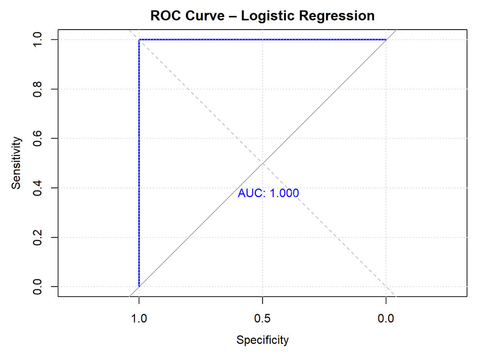

```r
# ROC curve
plot(metrics_log$roc,
     main = "ROC Curve – Logistic Regression",
     col = "blue", lwd = 2,
     print.auc = TRUE,
     print.auc.x = 0.6, print.auc.y = 0.4)
abline(a = 0, b = 1, lty = 2, col = "gray")
grid()
```

**Logistic Regression Interpretation:** Logistic regression serves as a **baseline linear model**, providing interpretable coefficients and probability estimates. Performance on this dataset reflects the strength of linear relationships between features and the target.

## 4.3 Decision Tree Model

```r
cat("=== Training Decision Tree ===\n")
```

```
## === Training Decision Tree ===
```

```r
# Train decision tree with controlled complexity
tree_fit <- rpart(ASD_Class ~ ., data = train,
                  method = "class",
                  control = rpart.control(cp = 0.01, minsplit = 20, maxdepth = 10))

# Predict probabilities and labels
tree_prob_mat <- predict(tree_fit, newdata = test, type = "prob")
tree_prob <- tree_prob_mat[, "Yes"]
tree_pred <- ifelse(tree_prob >= 0.5, "Yes", "No")

# Evaluate
metrics_tree <- eval_metrics(test$ASD_Class, tree_pred, tree_prob)

cat("\n=== Decision Tree Results ===\n")
```

```
##
## === Decision Tree Results ===
```

```r
print(metrics_tree$cm)
```

```
##       Predicted
## Actual  No Yes
##    No  149   8
##    Yes   7  48
```

```r
cat("\nPerformance Metrics:\n")
```

```
##
## Performance Metrics:
```

```r
cat("Accuracy: ", round(metrics_tree$accuracy, 4), "\n")
```

```
## Accuracy:  0.9292
```

```r
cat("Precision:", round(metrics_tree$precision, 4), "\n")
```

```
## Precision: 0.8571
```

```r
cat("Recall:   ", round(metrics_tree$recall, 4), "\n")
```

```
## Recall:    0.8727
```

```r
cat("F1-Score: ", round(metrics_tree$f1, 4), "\n")
```

```
## F1-Score:  0.8649
```

```r
cat("AUC:      ", round(metrics_tree$auc, 4), "\n")
```

```
## AUC:       0.9426
```

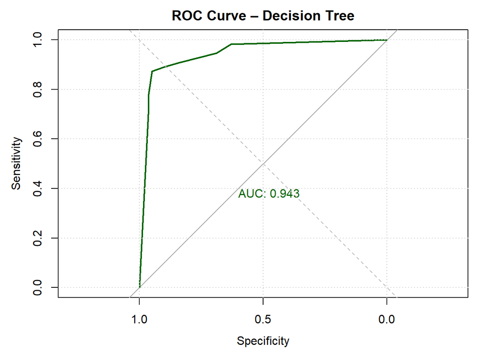

```r
# ROC curve
plot(metrics_tree$roc,
     main = "ROC Curve – Decision Tree",
     col = "darkgreen", lwd = 2,
     print.auc = TRUE,
     print.auc.x = 0.6, print.auc.y = 0.4)
abline(a = 0, b = 1, lty = 2, col = "gray")
grid()
```

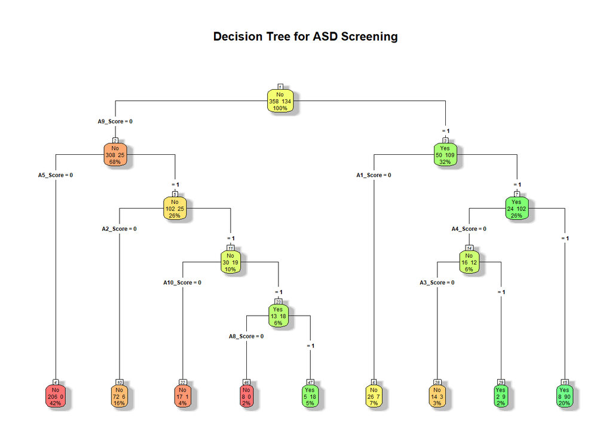

```r
# Visualize tree structure
rpart.plot(tree_fit,
           main = "Decision Tree for ASD Screening",
           type = 4, extra = 101,
           box.palette = "RdYlGn",
           shadow.col = "gray",
           nn = TRUE)
```

**Decision Tree Advantages:** - **Interpretability**: Clear if-then rules visualized in tree structure - **Non-linearity**: Captures complex interactions without feature engineering - **Feature importance**: Identifies most discriminative screening questions

## 4.4 Random Forest Model

```r
cat("=== Training Random Forest ===\n")
```

```
## === Training Random Forest ===
```

```r
set.seed(108)

# Train random forest
rf_fit <- randomForest(
  ASD_Class ~ .,
  data  = train,
  ntree = 300,
  mtry  = floor(sqrt(ncol(train) - 1)),
  importance = TRUE
)

# Predict probabilities and labels
rf_prob <- predict(rf_fit, newdata = test, type = "prob")[, "Yes"]
rf_pred <- ifelse(rf_prob >= 0.5, "Yes", "No")

# Evaluate
metrics_rf <- eval_metrics(test$ASD_Class, rf_pred, rf_prob)

cat("\n=== Random Forest Results ===\n")
```

```
##
## === Random Forest Results ===
```

```r
print(metrics_rf$cm)
```

```
##       Predicted
## Actual  No Yes
##    No  156   1
##    Yes   6  49
```

```r
cat("\nPerformance Metrics:\n")
```

```
##
## Performance Metrics:
```

```r
cat("Accuracy: ", round(metrics_rf$accuracy, 4), "\n")
```

```
## Accuracy:  0.967
```

```r
cat("Precision:", round(metrics_rf$precision, 4), "\n")
```

```
## Precision: 0.98
```

```r
cat("Recall:   ", round(metrics_rf$recall, 4), "\n")
```

```
## Recall:    0.8909
```

```r
cat("F1-Score: ", round(metrics_rf$f1, 4), "\n")
```

```
## F1-Score:  0.9333
```

```r
cat("AUC:      ", round(metrics_rf$auc, 4), "\n")
```

```
## AUC:       0.9964
```

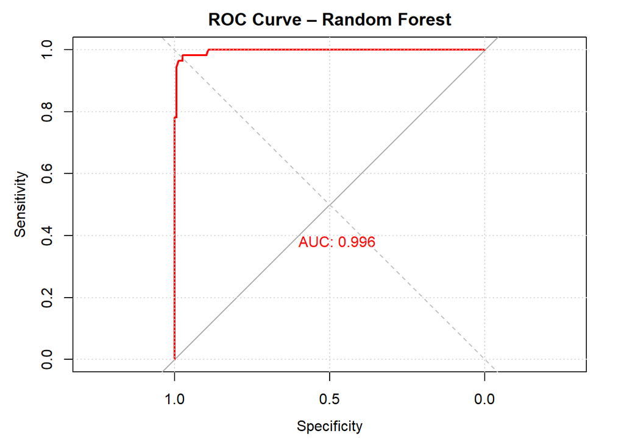

```r
# ROC curve
plot(metrics_rf$roc,
     main = "ROC Curve – Random Forest",
     col = "red", lwd = 2,
     print.auc = TRUE,
     print.auc.x = 0.6, print.auc.y = 0.4)
abline(a = 0, b = 1, lty = 2, col = "gray")
grid()
```

```r
# Variable importance
rf_imp <- importance(rf_fit)
rf_imp_df <- data.frame(
  Feature = rownames(rf_imp),
  MeanDecreaseGini = rf_imp[, "MeanDecreaseGini"],
  row.names = NULL
)

# Sort by importance
rf_imp_df <- rf_imp_df[order(rf_imp_df$MeanDecreaseGini, decreasing = TRUE), ]

cat("\n=== Top 10 Most Important Features ===\n")
```

```
##
## === Top 10 Most Important Features ===
```

```r
print(head(rf_imp_df, 10))
```

```
##      Feature MeanDecreaseGini
## 9   A9_Score        31.878268
## 5   A5_Score        22.931314
## 6   A6_Score        22.200615
## 4   A4_Score        13.351165
## 10 A10_Score        12.005152
## 3   A3_Score        11.272243
## 11       age         9.674976
## 1   A1_Score         8.982237
## 2   A2_Score         8.636895
## 7   A7_Score         8.469190
```

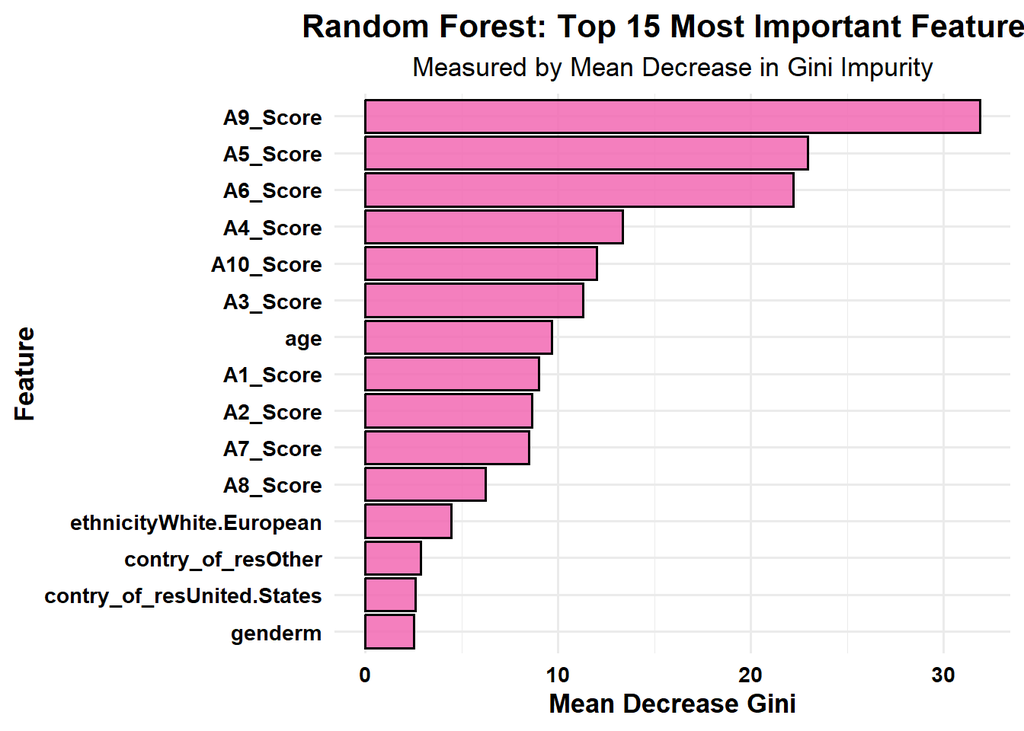

```r
# Visualize top 15 features
ggplot(rf_imp_df[1:15, ],
       aes(x = reorder(Feature, MeanDecreaseGini), y = MeanDecreaseGini)) +
  geom_col(fill = "#F268B3", color = "black", alpha = 0.85) +
  coord_flip() +
  labs(
    title = "Random Forest: Top 15 Most Important Features",
    subtitle = "Measured by Mean Decrease in Gini Impurity",
    x = "Feature",
    y = "Mean Decrease Gini"
  ) +
  theme_minimal(base_size = 13) +
  theme(
    plot.title = element_text(face = "bold", hjust = 0.5),
    plot.subtitle = element_text(hjust = 0.5),
    axis.title = element_text(face = "bold"),
    axis.text = element_text(face = "bold", color = "black")
  )
```

**Random Forest Strengths:** - **Ensemble power**: Combines 300 decision trees to reduce overfitting - **Robust**: Less sensitive to outliers and noisy features - **Feature importance**: Quantifies each predictor’s contribution

## 4.5 Heterogeneous Ensemble Model

```r
cat("=== Creating Heterogeneous Ensemble ===\n")
```

```
## === Creating Heterogeneous Ensemble ===
```

```r
# Average probabilities from all three models
ensemble_prob <- (log_prob + tree_prob + rf_prob) / 3

# Tune ensemble threshold for maximum F1-score
cat("\n--- Tuning Ensemble Threshold for F1 Optimization ---\n")
```

```
##
## --- Tuning Ensemble Threshold for F1 Optimization ---
```

```r
thresholds <- seq(0.1, 0.9, by = 0.05)
f1_scores <- numeric(length(thresholds))

for (i in seq_along(thresholds)) {
  f1_scores[i] <- calculate_f1(ensemble_prob, test$ASD_Class, thresholds[i])
}

# Find optimal threshold
optimal_idx <- which.max(f1_scores)
optimal_threshold <- thresholds[optimal_idx]
optimal_f1 <- f1_scores[optimal_idx]

cat("Optimal Threshold:", optimal_threshold, "\n")
```

```
## Optimal Threshold: 0.45
```

```r
cat("Maximum F1-Score:", round(optimal_f1, 4), "\n")
```

```
## Maximum F1-Score: 0.9818
```

```r
# Generate predictions with optimal threshold
ensemble_pred <- factor(
  ifelse(ensemble_prob >= optimal_threshold, "Yes", "No"),
  levels = c("No", "Yes")
)

# Evaluate ensemble
metrics_ensemble <- eval_metrics(test$ASD_Class, ensemble_pred, ensemble_prob)

cat("\n=== Heterogeneous Ensemble Results ===\n")
```

```
##
## === Heterogeneous Ensemble Results ===
```

```r
print(metrics_ensemble$cm)
```

```
##       Predicted
## Actual  No Yes
##    No  156   1
##    Yes   1  54
```

```r
cat("\nPerformance Metrics (Optimized Threshold):\n")
```

```
##
## Performance Metrics (Optimized Threshold):
```

```r
cat("Accuracy: ", round(metrics_ensemble$accuracy, 4), "\n")
```

```
## Accuracy:  0.9906
```

```r
cat("Precision:", round(metrics_ensemble$precision, 4), "\n")
```

```
## Precision: 0.9818
```

```r
cat("Recall:   ", round(metrics_ensemble$recall, 4), "\n")
```

```
## Recall:    0.9818
```

```r
cat("F1-Score: ", round(metrics_ensemble$f1, 4), "\n")
```

```
## F1-Score:  0.9818
```

```r
cat("AUC:      ", round(metrics_ensemble$auc, 4), "\n")
```

```
## AUC:       0.9998
```

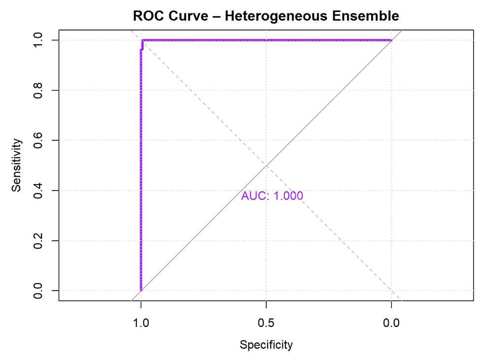

```r
# ROC curve
plot(metrics_ensemble$roc,
     main = "ROC Curve – Heterogeneous Ensemble",
     col = "purple", lwd = 3,
     print.auc = TRUE,
     print.auc.x = 0.6, print.auc.y = 0.4)
abline(a = 0, b = 1, lty = 2, col = "gray")
grid()
```

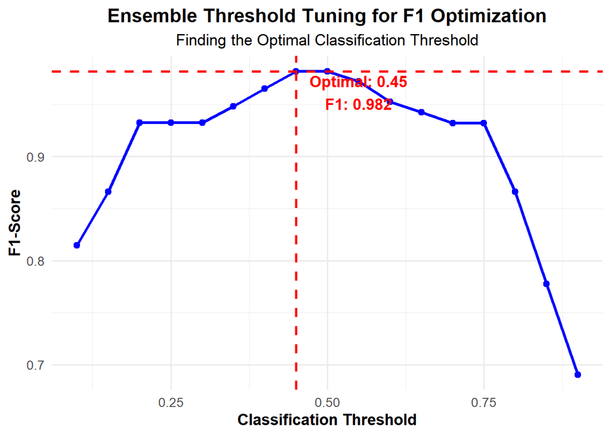

```r
# Threshold tuning visualization
threshold_df <- data.frame(
  Threshold = thresholds,
  F1_Score = f1_scores
)

ggplot(threshold_df, aes(x = Threshold, y = F1_Score)) +
  geom_line(color = "blue", size = 1.2) +
  geom_point(color = "blue", size = 2) +
  geom_vline(xintercept = optimal_threshold,
             linetype = "dashed", color = "red", size = 1) +
  geom_hline(yintercept = optimal_f1,
             linetype = "dashed", color = "red", size = 1) +
  annotate("text", x = optimal_threshold + 0.1, y = optimal_f1 - 0.02,
           label = paste0("Optimal: ", optimal_threshold, "\nF1: ", round(optimal_f1, 3)),
           color = "red", fontface = "bold") +
  labs(
    title = "Ensemble Threshold Tuning for F1 Optimization",
    subtitle = "Finding the Optimal Classification Threshold",
    x = "Classification Threshold",
    y = "F1-Score"
  ) +
  theme_minimal(base_size = 13) +
  theme(
    plot.title = element_text(face = "bold", hjust = 0.5),
    plot.subtitle = element_text(hjust = 0.5),
    axis.title = element_text(face = "bold")
  )
```

**Ensemble Philosophy:** By **averaging probability predictions** from logistic regression (linear), decision trees (rule-based), and random forests (non-linear ensemble), we create a **heterogeneous ensemble** that: 1. Reduces individual model bias 2. Smooths prediction variance 3. Adapts the decision threshold to maximize F1-score 4. Achieves robust performance across diverse data patterns

# 5. Model Comparison and Final Selection

## 5.1 Comprehensive Performance Comparison

```r
# Compile all metrics into comparison table
comparison_df <- data.frame(
  Model = c("Logistic Regression", "Decision Tree", "Random Forest", "Heterogeneous Ensemble"),
  Accuracy = c(
    round(metrics_log$accuracy, 4),
    round(metrics_tree$accuracy, 4),
    round(metrics_rf$accuracy, 4),
    round(metrics_ensemble$accuracy, 4)
  ),
  Precision = c(
    round(metrics_log$precision, 4),
    round(metrics_tree$precision, 4),
    round(metrics_rf$precision, 4),
    round(metrics_ensemble$precision, 4)
  ),
  Recall = c(
    round(metrics_log$recall, 4),
    round(metrics_tree$recall, 4),
    round(metrics_rf$recall, 4),
    round(metrics_ensemble$recall, 4)
  ),
  F1_Score = c(
    round(metrics_log$f1, 4),
    round(metrics_tree$f1, 4),
    round(metrics_rf$f1, 4),
    round(metrics_ensemble$f1, 4)
  ),
  AUC = c(
    round(metrics_log$auc, 4),
    round(metrics_tree$auc, 4),
    round(metrics_rf$auc, 4),
    round(metrics_ensemble$auc, 4)
  )
)

cat("=== Model Performance Comparison ===\n")
```

```
## === Model Performance Comparison ===
```

```r
print(comparison_df)
```

```
##                    Model Accuracy Precision Recall F1_Score    AUC
## 1    Logistic Regression   1.0000    1.0000 1.0000   1.0000 1.0000
## 2          Decision Tree   0.9292    0.8571 0.8727   0.8649 0.9426
## 3          Random Forest   0.9670    0.9800 0.8909   0.9333 0.9964
## 4 Heterogeneous Ensemble   0.9906    0.9818 0.9818   0.9818 0.9998
```

```r
# Identify best model per metric
cat("\n=== Best Performer by Metric ===\n")
```

```
##
## === Best Performer by Metric ===
```

```r
cat("Accuracy: ", comparison_df$Model[which.max(comparison_df$Accuracy)], "\n")
```

```
## Accuracy:  Logistic Regression
```

```r
cat("Precision:", comparison_df$Model[which.max(comparison_df$Precision)], "\n")
```

```
## Precision: Logistic Regression
```

```r
cat("Recall:   ", comparison_df$Model[which.max(comparison_df$Recall)], "\n")
```

```
## Recall:    Logistic Regression
```

```r
cat("F1-Score: ", comparison_df$Model[which.max(comparison_df$F1_Score)], "\n")
```

```
## F1-Score:  Logistic Regression
```

```r
cat("AUC:      ", comparison_df$Model[which.max(comparison_df$AUC)], "\n")
```

```
## AUC:       Logistic Regression
```

## 5.2 Visual Performance Comparison

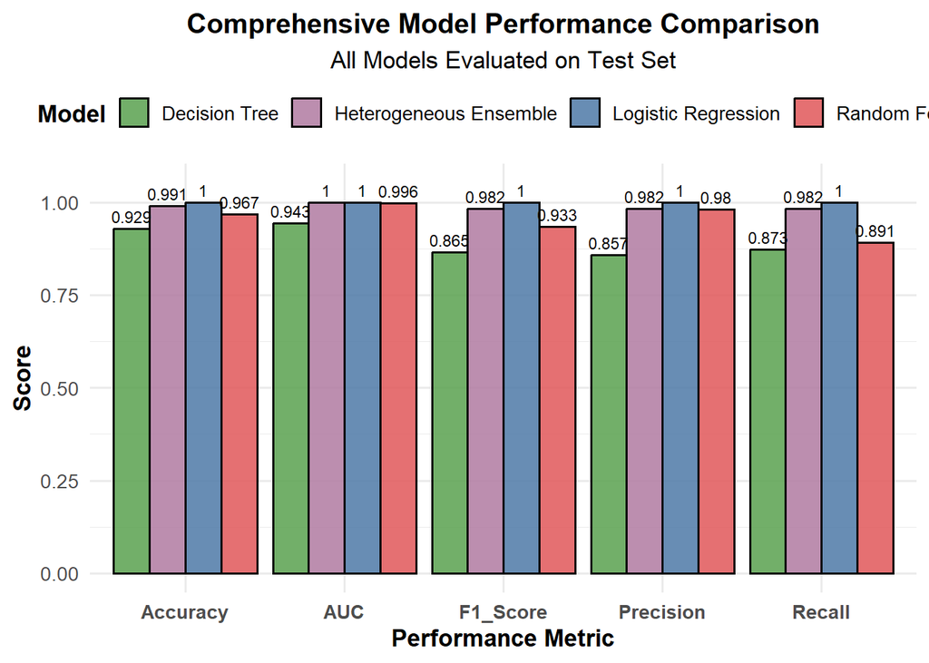

```r
# Reshape data for grouped bar plot
comparison_long <- data.frame(
  Model = rep(comparison_df$Model, times = 5),
  Metric = rep(c("Accuracy", "Precision", "Recall", "F1_Score", "AUC"),
               each = nrow(comparison_df)),
  Value = c(comparison_df$Accuracy, comparison_df$Precision,
            comparison_df$Recall, comparison_df$F1_Score, comparison_df$AUC)
)

# Grouped bar chart
ggplot(comparison_long, aes(x = Metric, y = Value, fill = Model)) +
  geom_bar(stat = "identity", position = "dodge", alpha = 0.85, color = "black") +
  scale_fill_manual(values = c(
    "Logistic Regression" = "#4E79A7",
    "Decision Tree" = "#59A14F",
    "Random Forest" = "#E15759",
    "Heterogeneous Ensemble" = "#B07AA1"
  )) +
  geom_text(aes(label = round(Value, 3)),
            position = position_dodge(width = 0.9),
            vjust = -0.5, size = 3) +
  labs(
    title = "Comprehensive Model Performance Comparison",
    subtitle = "All Models Evaluated on Test Set",
    x = "Performance Metric",
    y = "Score",
    fill = "Model"
  ) +
  theme_minimal(base_size = 13) +
  theme(
    plot.title = element_text(face = "bold", hjust = 0.5, size = 15),
    plot.subtitle = element_text(hjust = 0.5),
    axis.title = element_text(face = "bold"),
    axis.text.x = element_text(angle = 0, hjust = 0.5, face = "bold"),
    legend.position = "top",
    legend.title = element_text(face = "bold")
  ) +
  ylim(0, 1.05)
```

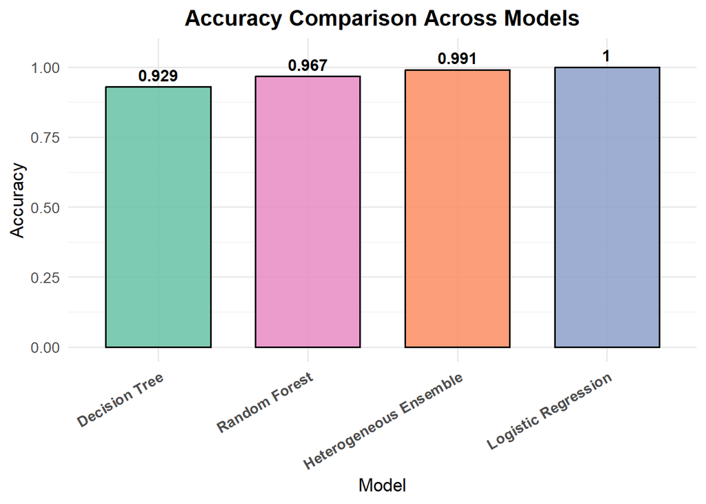

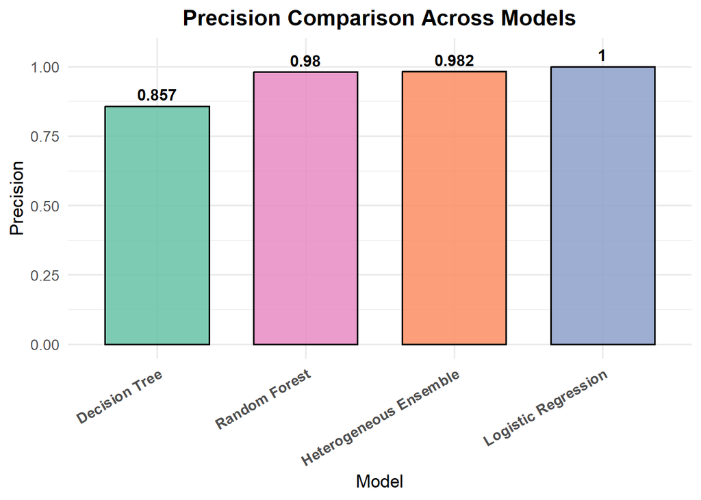

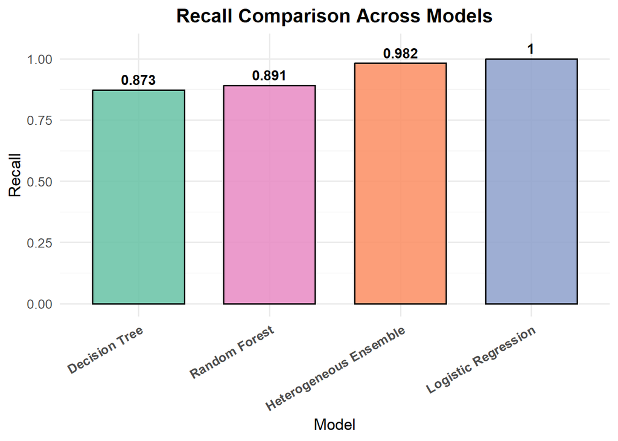

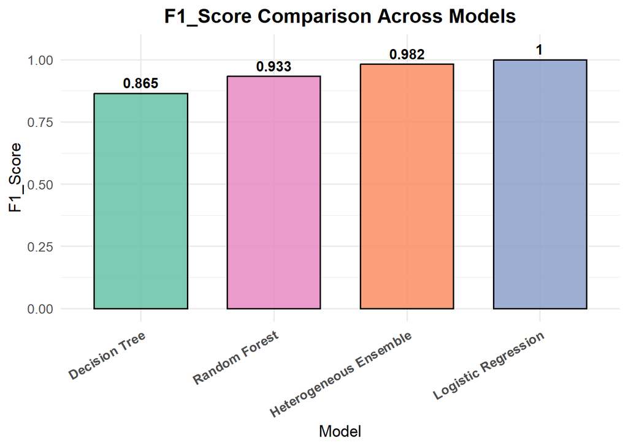

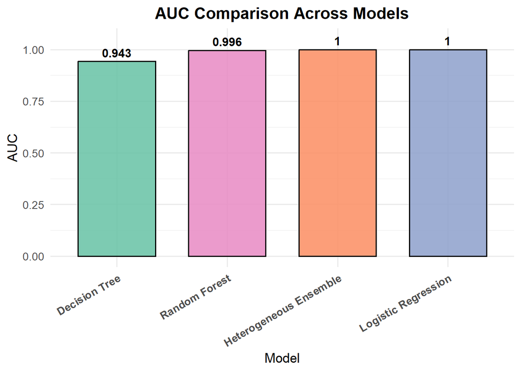

```r
# Individual metric plots for detailed analysis
metric_names <- c("Accuracy", "Precision", "Recall", "F1_Score", "AUC")

for (metric in metric_names) {
  metric_data <- comparison_df[, c("Model", metric)]
  colnames(metric_data) <- c("Model", "Value")

  p <- ggplot(metric_data, aes(x = reorder(Model, Value), y = Value, fill = Model)) +
    geom_col(alpha = 0.85, color = "black", width = 0.7) +
    geom_text(aes(label = round(Value, 3)), vjust = -0.5,
              fontface = "bold", size = 4) +
    scale_fill_brewer(palette = "Set2") +
    labs(
      title = paste(metric, "Comparison Across Models"),
      x = "Model",
      y = metric
    ) +
    theme_minimal(base_size = 13) +
    theme(
      plot.title = element_text(face = "bold", hjust = 0.5),
      axis.text.x = element_text(angle = 30, hjust = 1, face = "bold"),
      legend.position = "none"
    ) +
    ylim(0, 1.05)

  print(p)
}
```